# STAT497 PROJECT

**Bilgehan Aydoğdu** **2428886**

- Firstly, the necessary libraries were uploaded.

```r
library(TSA)
```

```r
library(ggplot2)
library(forecast)
library(fpp2)
library(tseries)
library(gridExtra)
library(pdR)
library(tidyverse)
library(tibbletime)
library(timetk)
library(magrittr)
library(tsibble)
library(dplyr)
```

# Data descripition

```r
data <- read.csv("NATURALGASD11 (1).csv")
head(data)
```

```
##         DATE NATURALGASD11
## 1 2000-01-01        1809.2
## 2 2000-02-01        1827.7
## 3 2000-03-01        1723.8
## 4 2000-04-01        1840.2
## 5 2000-05-01        1970.4
## 6 2000-06-01        1880.5
```

```r
data1 <- ts(na.omit(data[,2]), frequency = 12, start = c(2000, 1))# Create time series object
data1
```

```
##         Jan    Feb    Mar    Apr    May    Jun    Jul    Aug    Sep    Oct
## 2000 1809.2 1827.7 1723.8 1840.2 1970.4 1880.5 1737.4 1850.6 1858.3 1872.3
## 2001 1925.1 1881.0 1894.8 1871.8 1833.7 1794.0 1821.4 1869.0 1882.2 1968.0
## 2002 1785.8 1821.9 1910.9 1961.5 1940.3 1973.7 1988.0 1925.6 1940.5 1965.0
## 2003 1938.2 2028.6 1865.0 1833.8 1823.1 1689.6 1807.8 1836.5 1801.2 1852.4
## 2004 1927.0 1954.9 1789.1 1849.0 1895.6 1822.3 1778.9 1741.8 1868.8 1855.7
## 2005 1850.9 1820.1 1886.1 1836.2 1836.7 1872.4 1885.4 1866.9 1796.9 1696.4
## 2006 1567.6 1744.8 1825.1 1793.7 1850.8 1886.9 1965.5 1923.3 1841.5 1948.5
## 2007 1788.2 2092.2 1839.3 1936.0 1902.6 1889.5 1854.3 2082.5 2001.4 1920.4
## 2008 1966.0 1959.7 1991.0 1958.1 1934.6 1952.4 1910.2 1845.1 1828.2 1925.4
## 2009 1952.6 1907.8 1923.7 1882.7 1846.6 1860.5 1848.6 1905.9 1962.6 1954.9
## 2010 2008.2 2040.3 1919.5 1841.7 1982.7 2010.9 2027.1 2062.8 2028.1 1953.6
## 2011 2070.3 2029.8 2010.0 2002.2 2035.3 2020.5 2089.5 2080.1 2043.3 2044.8
## 2012 1988.4 1998.1 1918.0 2155.8 2278.2 2277.9 2285.6 2213.7 2215.7 2222.8
## 2013 2089.2 2158.9 2264.8 2183.8 2121.8 2117.7 2127.2 2128.1 2154.1 2176.1
```

[output cut: 35 more lines]

**Time series plot**

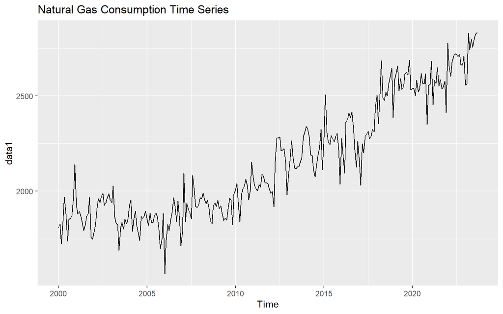

```r
# Time series plot
autoplot(data1,main = "Natural Gas Consumption Time Series")# there is a slight increase trend
```

By looking at the plot, we may say that there is a slight increasing trend.

**Splitting data as train and test**

```r
train <- data[1:273,]

test <- data[274:285,]

ts_train<-ts(train[,2],frequency= 12,start = c(2000,1))
```

# Anomaly Detection

-We convert “train” to a tibble format

```r
train <- as_tibble(train)
class(train)
```

```
## [1] "tbl_df"     "tbl"        "data.frame"
```

```r
train$DATE <- as.Date(train$DATE,format="%Y-%m-%d")
```

```
## Converting from tbl_df to tbl_time.
## Auto-index message: index = DATE
```

```
## frequency = 12 months
```

```
## trend = 60 months
```

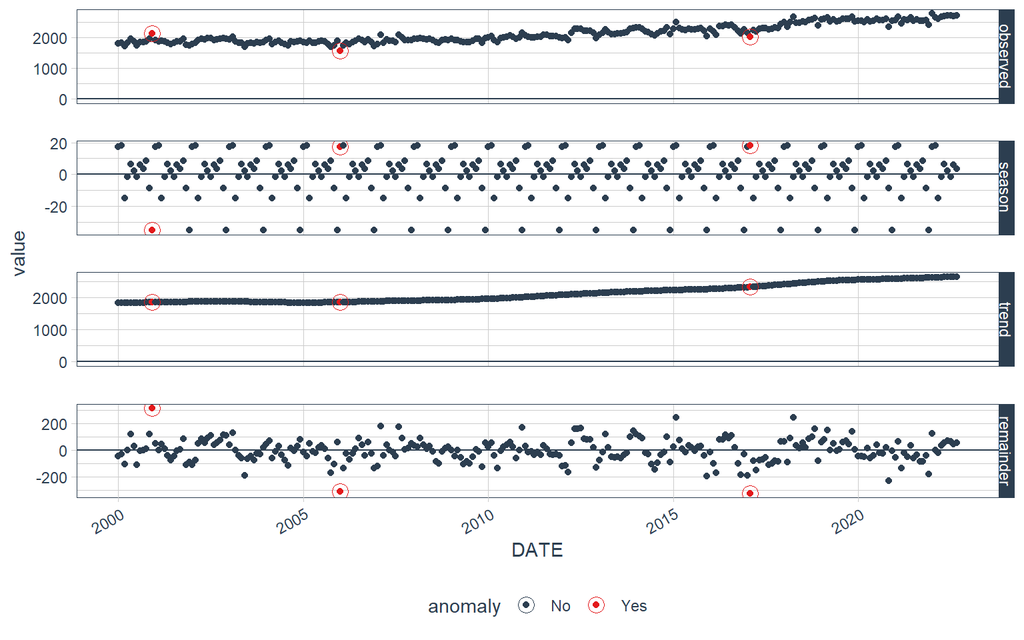

```r
library(tidyverse)  # Core data manipulation and visualization libraries
library(tidyquant)  # Used for business-ready ggplot themes
library(anomalize)  # Identify and clean time series anomalies
library(timetk)     # Time Series Machine Learning Features
library(knitr)      # For kable() function: This is a very simple table generator.

train %>%
  time_decompose(NATURALGASD11, method = "stl", frequency = "auto", trend = "auto") %>%
  anomalize(remainder, method = "gesd", alpha = 0.05, max_anoms = 0.2) %>%
  plot_anomaly_decomposition()
```

```
## Converting from tbl_df to tbl_time.
## Auto-index message: index = DATE
```

```
## frequency = 12 months
```

```
## trend = 60 months
```

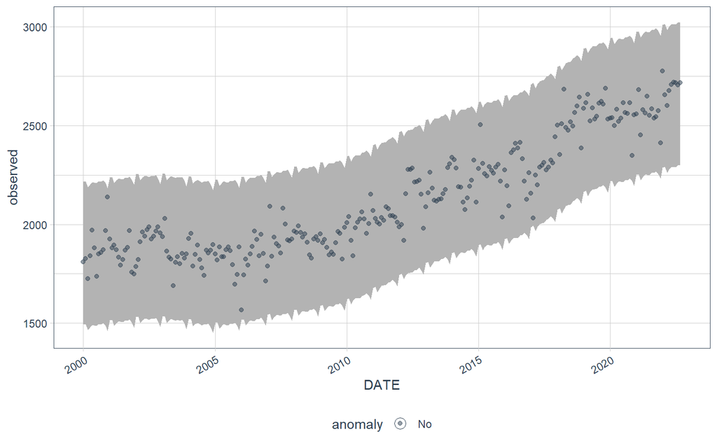

```r
train%>%
  time_decompose(NATURALGASD11) %>%
  anomalize(remainder,alpha=0.05) %>%
  time_recompose() %>%
  plot_anomalies(time_recomposed = TRUE, ncol = 3, alpha_dots = 0.5)
```

# Box-Cox transformation

```r
library(forecast)
lambda <- BoxCox.lambda(train)
lambda
```

```
## [1] 1
```

Since lambda value is 1, no need transformation.

# ACF and PACF

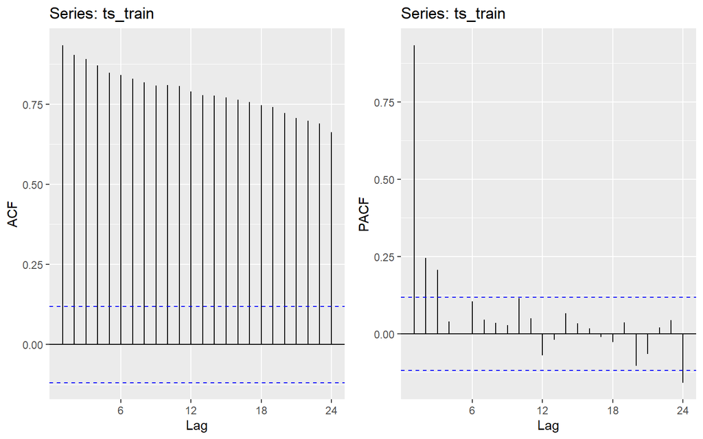

```r
library(gridExtra)
p1<-ggAcf(ts_train)
p2<-ggPacf(ts_train)
grid.arrange(p1,p2,nrow=1)
```

# KPSS, ADF, HEGY and Canova-Hansen Tests

**KPSS**

```r
library(tseries)
kpss.test(ts_train,null = "Level")
```

```
##
##  KPSS Test for Level Stationarity
##
## data:  ts_train
## KPSS Level = 4.2088, Truncation lag parameter = 5, p-value = 0.01
```

Since p value is less than alpha, we reject H0. That means we don’t have enough evidence to claim that the process is stationary.

Since we concluded that the series is not stationary, now we apply KPSS test a second time to determine which kind of trend exists in the series;

```r
kpss.test(ts_train,null=c("Trend"))
```

```
##
##  KPSS Test for Trend Stationarity
##
## data:  ts_train
## KPSS Trend = 0.72127, Truncation lag parameter = 5, p-value = 0.01
```

Since p value is smaller than alpha, we reject H0, That means We don’t have enough evidence to claim that the process has deterministic trend.

**ADF**

```r
library(fUnitRoots)
adfTest(ts_train, lags=1, type="c")
```

```
##
## Title:
##  Augmented Dickey-Fuller Test
##
## Test Results:
##   PARAMETER:
##     Lag Order: 1
##   STATISTIC:
##     Dickey-Fuller: -1.6421
##   P VALUE:
##     0.4454
##
## Description:
##  Sun Dec 24 12:38:25 2023 by user: Bilgehan
```

Since p value is greater than α=0.05 , we fail to reject H0.It means that we don’t have enough evidence to claim that we have a stationary system, like KPSS test.

```r
adfTest(train$NATURALGASD11, lags=1, type="ct")
```

```
##
## Title:
##  Augmented Dickey-Fuller Test
##
## Test Results:
##   PARAMETER:
##     Lag Order: 1
##   STATISTIC:
##     Dickey-Fuller: -5.2398
##   P VALUE:
##     0.01
##
## Description:
##  Sun Dec 24 12:38:25 2023 by user: Bilgehan
```

Since p value is smaller than α=0.05 , we reject H0. It mean non-stationary series have determenistic trend.

However, when we look time series plot of the series it is obvious that the series has a stochastic trend. So, we may ignore this part of the result of the adf-test.

**HEGY**

```r
ts_train <- BoxCox(ts_train,lambda)
library(pdR)
out<-HEGY.test(wts=ts_train, itsd=c(1,0,0), regvar=0, selectlags=list(mode="signf", Pmax=NULL))
out$stats
```

```
##                Stat. p-value
## tpi_1      0.4408395    0.10
## tpi_2     -4.9481954    0.01
## Fpi_3:4   24.2282934    0.01
## Fpi_5:6   18.5744756    0.01
## Fpi_7:8   25.0749823    0.01
## Fpi_9:10  25.0150074    0.01
## Fpi_11:12 12.8314572    0.01
## Fpi_2:12  23.0834266      NA
## Fpi_1:12  21.2772262      NA
```

**Canova-Hansen**

```r
library(uroot)
ch.test(ts_train,type = "dummy",sid=c(1:12)) #since we have monthly data, we use sid=c(1:12)
```

```
##
##  Canova and Hansen test for seasonal stability
##
## data:  ts_train
##
##      statistic pvalue
## [1,]    2.1871  0.274
## ---
## Signif. codes: 0 '***' 0.001 '**' 0.01 '*' 0.05 '.' 0.1 ' ' 1
##
## Test type: seasonal dummies
## NW covariance matrix lag order: 15
## First order lag: no
## Other regressors: no
## P-values: interpolation in original tables
```

Since p value (0.274) is greater α , we fail to reject H0. The series have purely deterministic seaonality (no seasonal unit root).

# DIFFERENCING

**Since there is a trend, we should remove it either by detrending or differencing.**

Number of differencing should be taken will be as follows;

```r
ndiffs(ts_train)
```

```
## [1] 1
```

We need to take one regular difference.

```r
diff.ts <- diff(ts_train) # regular diff
```

```r
library(fUnitRoots)
adfTest(diff.ts, lags=1, type="nc")
```

```
##
## Title:
##  Augmented Dickey-Fuller Test
##
## Test Results:
##   PARAMETER:
##     Lag Order: 1
##   STATISTIC:
##     Dickey-Fuller: -18.1523
##   P VALUE:
##     0.01
##
## Description:
##  Sun Dec 24 12:38:27 2023 by user: Bilgehan
```

Since p value is less than α, we reject H0. We have enough evidence to conclude that differenced series are stationary.

```r
library(pdR)
out1<-HEGY.test(wts=diff.ts, itsd=c(1,0,0), regvar=0, selectlags=list(mode="signf", Pmax=NULL))
out1$stats
```

```
##               Stat. p-value
## tpi_1     -6.441256    0.01
## tpi_2     -3.800795    0.01
## Fpi_3:4   24.549345    0.01
## Fpi_5:6    5.963202    0.01
## Fpi_7:8   31.221954    0.01
## Fpi_9:10  15.437007    0.01
## Fpi_11:12 19.395250    0.01
## Fpi_2:12  23.553592      NA
## Fpi_1:12  27.017100      NA
```

The output shows that the differenced series does not have regular or seasonal unit root since p values of tpi_1 and Fpi_11:12 is less than α value.

The trend is removed, We need to check time series plot, ACF and PACF.

-Time series plot;

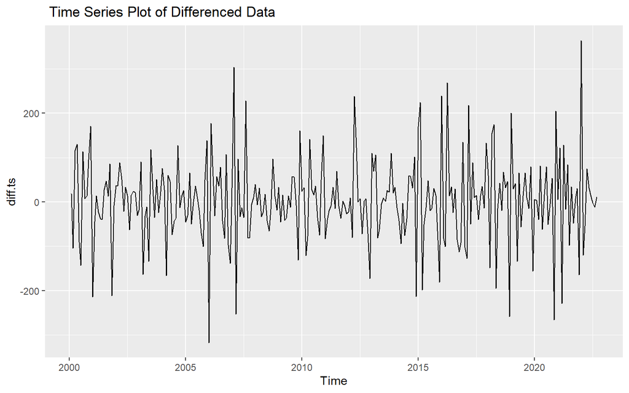

```r
autoplot(diff.ts,main = " Time Series Plot of Differenced Data")
```

-ACF and PACF

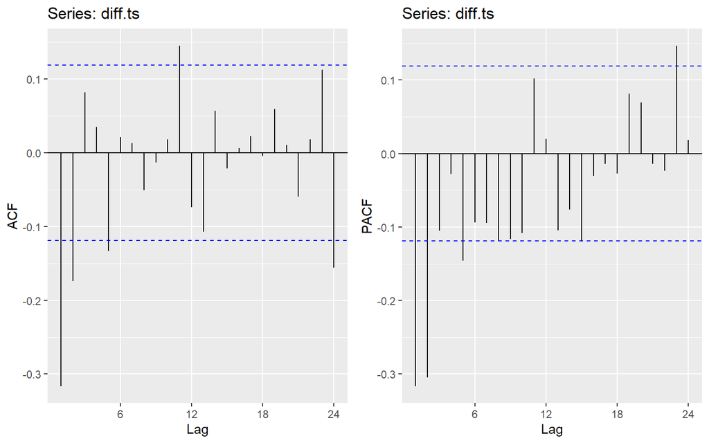

```r
p11<-ggAcf(diff.ts)
p22<-ggPacf(diff.ts)
grid.arrange(p11,p22,nrow=1)
```

We may suggest ARIMA(2,1,1) or ARIMA(2,1,2) models.

```r
library(TSA)
eacf(diff.ts)
```

```
## AR/MA
##   0 1 2 3 4 5 6 7 8 9 10 11 12 13
## 0 x x o o x o o o o o x  o  o  o
## 1 x x o o x o o o o o x  o  x  o
## 2 x o x o x o o o o o o  o  x  o
## 3 x o x x o o o o o o o  o  x  o
## 4 x x x o o o o o o o o  o  o  o
## 5 x x x o o o o o o o o  o  x  o
## 6 x x x o o o o x o o o  o  o  o
## 7 x x x o o o x o o o o  o  o  o
```

```r
library(forecast)
auto.arima(diff.ts)
```

```
## Series: diff.ts
## ARIMA(1,0,1)(2,0,0)[12] with non-zero mean
##
## Coefficients:
##          ar1      ma1     sar1     sar2    mean
##       0.3058  -0.8377  -0.0842  -0.2335  3.1478
## s.e.  0.0831   0.0489   0.0625   0.0638  0.9131
##
## sigma^2 = 6799:  log likelihood = -1584.63
## AIC=3181.27   AICc=3181.59   BIC=3202.9
```

**“auto.arima” and “eacf” functions do not suggest any healhty model. So, we use the model that found by observing ACF and PACF of differenced series.**

# Model Identification and Paramater Estimation in Time Series Model

We will select one of the models between ARIMA(2,1,1) or ARIMA(2,1,2) models. To select we should decide which one is better.

```r
fit1<-Arima(ts_train,order = c(2, 1, 2))
fit1
```

```
## Series: ts_train
## ARIMA(2,1,2)
##
## Coefficients:
##           ar1     ar2     ma1      ma2
##       -0.6037  0.2835  0.1210  -0.7467
## s.e.   0.2106  0.1223  0.1949   0.1690
##
## sigma^2 = 7328:  log likelihood = -1594.55
## AIC=3199.11   AICc=3199.33   BIC=3217.14
```

```r
fit2<-Arima(ts_train,order = c(2, 1, 1))
fit2
```

```
## Series: ts_train
## ARIMA(2,1,1)
##
## Coefficients:
##          ar1      ar2      ma1
##       0.3205  -0.0065  -0.8059
## s.e.  0.0920   0.0754   0.0701
##
## sigma^2 = 7308:  log likelihood = -1594.68
## AIC=3197.35   AICc=3197.5   BIC=3211.77
```

Since fit2 has smaller AIC and BIC, ARIMA(2,1,1) is better,we select this model and continue our analyzes with this model.

## Normality of Residuals

Firstly, obtain the residuals,

```r
r=resid(fit2)/sd(residuals(fit2))
head(r)
```

```
##              Jan         Feb         Mar         Apr         May         Jun
## 2000  0.02145951  0.19526009 -1.09054550  0.91893938  1.76550282 -0.16084562
```

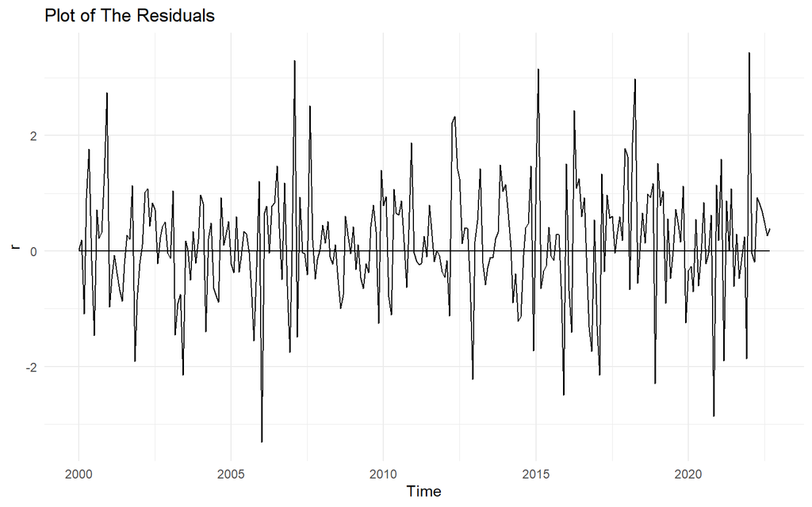

```r
autoplot(r)+geom_line(y=0)+theme_minimal()+ggtitle("Plot of The Residuals")
```

Reiduals are scattered around zero and it can be interpreted as zero mean.

# Forecast

To forecast, we will use Holt’s method since there is a trend.

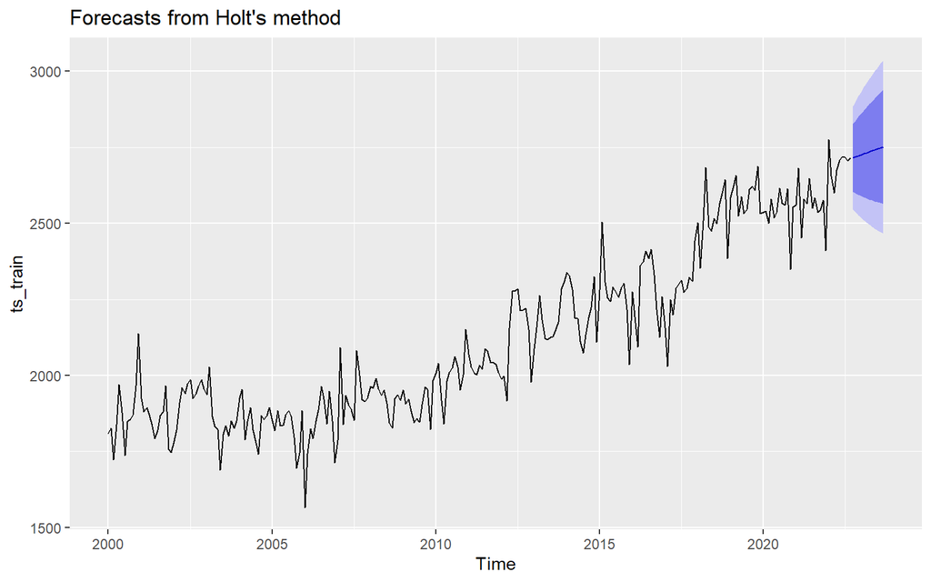

```r
holt.train <- holt(ts_train, h = 12)
autoplot(holt.train)# same number as the test data
```

```r
accuracy(holt.train)
```

```
##                       ME     RMSE      MAE        MPE     MAPE      MASE
## Training set -0.01325335 86.06779 64.82218 -0.1599801 3.092161 0.5847385
##                 ACF1
## Training set 0.10345
```